# iDEP: Investigating Differentially Expressed Genes

## If this site has contributed to your work, please cite our article:

Ge, S.X., Son, E.W. & Yao, R. iDEP: an integrated web application for differential expression and pathway analysis of RNA-Seq data. BMC Bioinformatics 19, 534 (2018). https://doi.org/10.1186/s12859-018-2486-6

## Summary

Read Counts data were analyzed using iDEP v2.4.4. The data was first filtered to remove reads below 0.5 CPM in at least 1 sample. Then the data was transformed with EdgeR using a pseudocount of 4. Missing values were imputed using geneMedian.

After mapping, there are 32833 unique genes in 158 samples. Of the 24127 genes passed filter, 24127 were converted to Ensembl/STRING gene IDs in our database. The remaining 0 genes were kept in the data using original IDs.

Differential expression analysis was performed using DESeq2 with an FDR cutoff of 0.1 and a minimum fold-change threshold of 2. Standard Wald test was used and independent filtering was enabled.

## Selected Comparison: Time_After_Treatment_min90-Time_After_Treatment_min0

Up-regulated genes: 157

Down-regulated genes: 246

## Top Up-regulated Genes

```r
if (!is.null(params$up_genes_table) && nrow(params$up_genes_table) > 0) {
  kbl(params$up_genes_table, escape = FALSE) %>%
    kable_classic(full_width = FALSE, html_font = "Cambria")
} else {
  print("No up-regulated genes found for this comparison.")
}
```

| Symbol | Ensembl ID | log2 FC | Adj. P-value | Description |
| --- | --- | --- | --- | --- |
| AT2G09785 | AT2G09785 | 15.741 | 1.17e-03 | NcRNA |
| AT1G05767 | AT1G05767 | 13.095 | 3.04e-12 | S-adenosyl-L-methionine-dependent methyltransferases superfamily protein |
| AT1G07500 | AT1G07500 | 12.906 | 1.97e-13 | Uncharacterized protein |
| MRD1 | AT1G53480 | 12.774 | 3.45e-10 | Mto 1 responding down 1 |
| AT1G04163 | AT1G04163 | 11.161 | 2.16e-02 | NcRNA |
| TAT3 | AT2G24850 | 3.408 | 6.43e-02 | Tyrosine aminotransferase 3 |
| AT1G27580 | AT1G27580 | 3.309 | 5.82e-02 | F-box protein (DUF295) |
| ARCK1 | AT4G11890 | 2.762 | 1.21e-03 | Protein kinase superfamily protein |
| AT5G06695 | AT5G06695 | 2.697 | 4.22e-02 | NcRNA |
| ATMG01280 | ATMG01280 | 2.442 | 2.88e-02 |  |
| CRK24 | AT4G23320 | 2.440 | 5.76e-02 | Cysteine-rich RLK (RECEPTOR-like protein kinase) 24 |
| AT5G01380 | AT5G01380 | 2.440 | 1.22e-02 | Homeodomain-like superfamily protein |
| RLP50 | AT4G13920 | 2.421 | 5.76e-02 | Receptor like protein 50 |
| ERF53 | AT2G20880 | 2.291 | 3.08e-02 | Integrase-type DNA-binding superfamily protein |
| WRKY30 | AT5G24110 | 2.077 | 3.60e-02 | WRKY DNA-binding protein 30 |
| DLAH | AT1G30370 | 2.039 | 3.58e-02 | Alpha/beta-Hydrolases superfamily protein |
| AT5G16960 | AT5G16960 | 2.035 | 7.12e-02 | Zinc-binding dehydrogenase family protein |
| HSFA6B | AT3G22830 | 1.979 | 1.52e-02 | Heat shock transcription factor A6B |
| PUB19 | AT1G60190 | 1.888 | 1.58e-02 | ARM repeat superfamily protein |
| PRR9 | AT2G46790 | 1.873 | 4.72e-04 | Pseudo-response regulator 9 |
| ASG4 | AT1G01520 | 1.854 | 2.17e-02 | Homeodomain-like superfamily protein |
| LTI78 | AT5G52310 | 1.851 | 1.22e-02 | Low-temperature-responsive protein 78 (LTI78) / desiccation-responsive protein 29A (RD29A) |
| AT5G01542 | AT5G01542 | 1.827 | 3.01e-02 | NcRNA |
| ABR1 | AT5G64750 | 1.821 | 7.28e-02 | Integrase-type DNA-binding superfamily protein |
| MYB15 | AT3G23250 | 1.820 | 8.32e-02 | Myb domain protein 15 |
| AT1G52855 | AT1G52855 | 1.813 | 3.66e-02 | Uncharacterized protein |
| RPS2 AT4G26090 | AT4G26090 | 1.796 | 1.91e-02 | NB-ARC domain-containing disease resistance protein |
| AT4G34550 | AT4G34550 | 1.796 | 2.76e-02 | F-box protein |
| AT1G24580 | AT1G24580 | 1.773 | 5.22e-02 | RING/U-box superfamily protein |
| CYP81D8 | AT4G37370 | 1.741 | 2.39e-02 | Cytochrome P450, family 81, subfamily D, polypeptide 8 |
| CGA1 | AT4G26150 | 1.718 | 1.14e-03 | Cytokinin-responsive gata factor 1 |
| SPX1 | AT5G20150 | 1.709 | 2.84e-03 | SPX domain-containing protein 1 |
| AT3G09450 | AT3G09450 | 1.706 | 2.41e-02 | Fusaric acid resistance family protein |
| AT5G02540 | AT5G02540 | 1.664 | 1.62e-03 | NAD(P)-binding Rossmann-fold superfamily protein |
| ABCG40 | AT1G15520 | 1.659 | 3.75e-02 | Pleiotropic drug resistance 12 |
| AT2G46670 | AT2G46670 | 1.654 | 8.47e-02 | CCT motif family protein |
| BBX31 | AT3G21890 | 1.648 | 2.76e-02 | B-box type zinc finger family protein |
| HAI1 | AT5G59220 | 1.619 | 4.96e-02 | PP2C protein (Clade A protein phosphatases type 2C) |
| AT3G54150 | AT3G54150 | 1.617 | 1.03e-02 | S-adenosyl-L-methionine-dependent methyltransferases superfamily protein |
| WRKY51 | AT5G64810 | 1.616 | 1.71e-02 | WRKY DNA-binding protein 51 |
| PAP17 | AT3G17790 | 1.602 | 1.51e-02 | Purple acid phosphatase 17 |
| AT3G24420 | AT3G24420 | 1.596 | 1.18e-04 | Alpha/beta-Hydrolases superfamily protein |
| DAR3 | AT5G66640 | 1.580 | 4.22e-02 | DA1-related protein 3 |
| G3Pp1 | AT3G47420 | 1.576 | 2.76e-03 | Putative glycerol-3-phosphate transporter 1 |
| AT1G51090 | AT1G51090 | 1.563 | 6.21e-02 | Heavy metal transport/detoxification superfamily protein |
| AT3G21330 | AT3G21330 | 1.558 | 3.91e-02 | Basic helix-loop-helix (bHLH) DNA-binding superfamily protein |
| AT2G45685 | AT2G45685 | 1.546 | 8.12e-02 | NcRNA |
| CRK14 | AT4G23220 | 1.542 | 3.11e-02 | Cysteine-rich RECEPTOR-like kinase |
| AFP1 | AT1G69260 | 1.542 | 2.84e-03 | ABI five binding protein |
| PRE5 | AT3G28857 | 1.541 | 6.11e-02 | Basic helix-loop-helix (bHLH) DNA-binding family protein |

## Top Down-regulated Genes

```r
if (!is.null(params$down_genes_table) && nrow(params$down_genes_table) > 0) {
  kbl(params$down_genes_table, escape = FALSE) %>%
    kable_classic(full_width = FALSE, html_font = "Cambria")
} else {
  print("No down-regulated genes found for this comparison.")
}
```

| Symbol | Ensembl ID | log2 FC | Adj. P-value | Description |
| --- | --- | --- | --- | --- |
| ATCG01000 | ATCG01000 | -27.029 | 3.70e-13 |  |
| GMD1 | AT5G66280 | -11.354 | 1.42e-12 | GDP-D-mannose 4,6-dehydratase 1 |
| AT1G09053 | AT1G09053 | -8.111 | 7.17e-03 | NcRNA |
| AT2G07751 ATMG00990 | ATMG00990 | -6.674 | 6.58e-02 | NADH:ubiquinone/plastoquinone oxidoreductase, chain 3 protein |
| AT1G18010 | AT1G18010 | -4.970 | 7.83e-02 | Major facilitator superfamily protein |
| AT1G33760 | AT1G33760 | -3.827 | 1.49e-02 | Integrase-type DNA-binding superfamily protein |
| AT4G05775 | AT4G05775 | -3.417 | 5.75e-03 | NcRNA |
| HSP17.6A | AT5G12030 | -3.343 | 3.01e-02 | Heat shock protein 17.6A |
| AT5G06235 | AT5G06235 | -3.268 | 1.91e-02 | NcRNA |
| ZAT7 | AT3G46090 | -3.250 | 1.69e-03 | C2H2 and C2HC zinc fingers superfamily protein |
| AT5G51190 | AT5G51190 | -3.122 | 7.26e-02 | Integrase-type DNA-binding superfamily protein |
| HSP17.4 | AT3G46230 | -2.899 | 4.71e-02 | Heat shock protein 17.4 |
| AT1G04433 | AT1G04433 | -2.674 | 8.38e-02 | NcRNA |
| DFR | AT5G42800 | -2.566 | 1.14e-03 | Dihydroflavonol 4-reductase |
| AT3G62950 | AT3G62950 | -2.563 | 1.61e-02 | Thioredoxin superfamily protein |
| CYP79F1 | AT1G16410 | -2.366 | 9.06e-03 | Cytochrome p450 79f1 |
| LDOX | AT4G22880 | -2.340 | 1.71e-03 | Leucoanthocyanidin dioxygenase |
| AT1G72910 | AT1G72910 | -2.303 | 4.72e-04 | Toll-Interleukin-Resistance (TIR) domain-containing protein |
| MYB76 | AT5G07700 | -2.139 | 4.27e-02 | Myb domain protein 76 |
| AT5MAT | AT3G29590 | -2.120 | 3.27e-03 | HXXXD-type acyl-transferase family protein |
| AT2G40435 | AT2G40435 | -2.118 | 1.17e-03 | Transcription factor SCREAM-like protein |
| UF3GT | AT5G54060 | -2.100 | 7.55e-03 | UDP-glucose:flavonoid 3-o-glucosyltransferase |
| AT1G33055 | AT1G33055 | -2.099 | 8.37e-02 | Uncharacterized protein |
| AT2G01610 | AT2G01610 | -2.044 | 1.18e-04 | Plant invertase/pectin methylesterase inhibitor superfamily protein |
| AT2G29300 | AT2G29300 | -1.997 | 4.08e-05 | NAD(P)-binding Rossmann-fold superfamily protein |
| TCP1 | AT1G67260 | -1.962 | 4.29e-02 | TCP family transcription factor |
| AT3G46890 | AT3G46890 | -1.952 | 2.27e-03 | Maternal effect embryo arrest protein |
| ORA47 | AT1G74930 | -1.929 | 9.08e-03 | Integrase-type DNA-binding superfamily protein |
| BGLU47 | AT4G21760 | -1.913 | 9.76e-04 | Beta-glucosidase 47 |
| AT4G32480 | AT4G32480 | -1.905 | 4.82e-03 | Sugar phosphate exchanger, putative (DUF506) |
| LBD41 | AT3G02550 | -1.885 | 4.20e-03 | LOB domain-containing protein 41 |
| CSLB06 | AT4G15320 | -1.883 | 2.81e-03 | Cellulose synthase-like B6 |
| AT3G03130 | AT3G03130 | -1.822 | 1.03e-02 | LisH domain-like protein |
| AT4G14090 | AT4G14090 | -1.817 | 7.52e-03 | UDP-Glycosyltransferase superfamily protein |
| AT5G59390 | AT5G59390 | -1.796 | 8.37e-02 | XH/XS domain-containing protein |
| AT5G45650 | AT5G45650 | -1.783 | 8.74e-06 | Subtilase family protein |
| AT5G45700 | AT5G45700 | -1.742 | 2.59e-02 | Haloacid dehalogenase-like hydrolase (HAD) superfamily protein |
| AT3G24230 | AT3G24230 | -1.731 | 2.80e-02 | Pectate lyase family protein |
| AT5G59330 | AT5G59330 | -1.719 | 2.54e-03 | Bifunctional inhibitor/lipid-transfer protein/seed storage 2S albumin superfamily protein |
| AT2G47780 | AT2G47780 | -1.715 | 4.58e-02 | Rubber elongation factor protein (REF) |
| OFP16 | AT2G32100 | -1.715 | 7.86e-04 | Ovate family protein 16 |
| MEE3 | AT2G21650 | -1.704 | 6.90e-04 | Homeodomain-like superfamily protein |
| AT1G13650 | AT1G13650 | -1.681 | 1.06e-02 | Uncharacterized protein |
| SRS6 | AT3G54430 | -1.680 | 2.72e-02 | SHI-related sequence 6 |
| ACHT5 | AT5G61440 | -1.675 | 1.98e-03 | Atypical CYS HIS rich thioredoxin 5 |
| MYB29 | AT5G07690 | -1.671 | 1.14e-02 | Myb domain protein 29 |
| AT1G76955 | AT1G76955 | -1.663 | 5.95e-02 | Uncharacterized protein |
| AT5G66840 | AT5G66840 | -1.658 | 9.07e-03 | SAP domain-containing protein |
| BT5 | AT4G37610 | -1.647 | 6.50e-03 | BTB and TAZ domain protein 5 |
| UBC12 | AT3G08700 | -1.645 | 1.63e-02 | Ubiquitin-conjugating enzyme 12 |

## DEG Heatmap

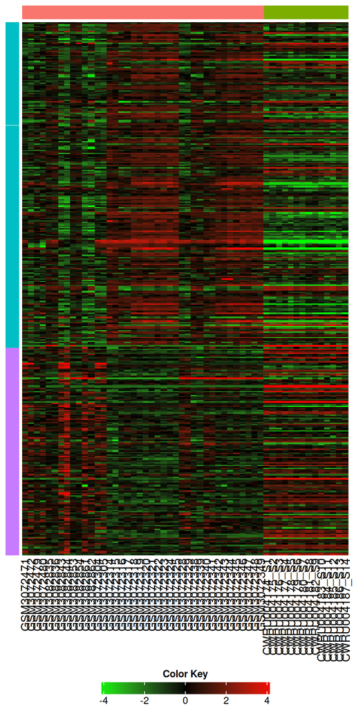

```r
if (!is.null(params$heat_data) && !is.null(params$heat_bar)) {
  heat_colors <- unlist(strsplit(params$heatmap_color_select, "-"))

  deg_heatmap(
    df = params$heat_data,
    bar = params$heat_bar,
    heatmap_color_select = heat_colors,
    cluster_rows = FALSE
  )
}
```

## Volcano Plot

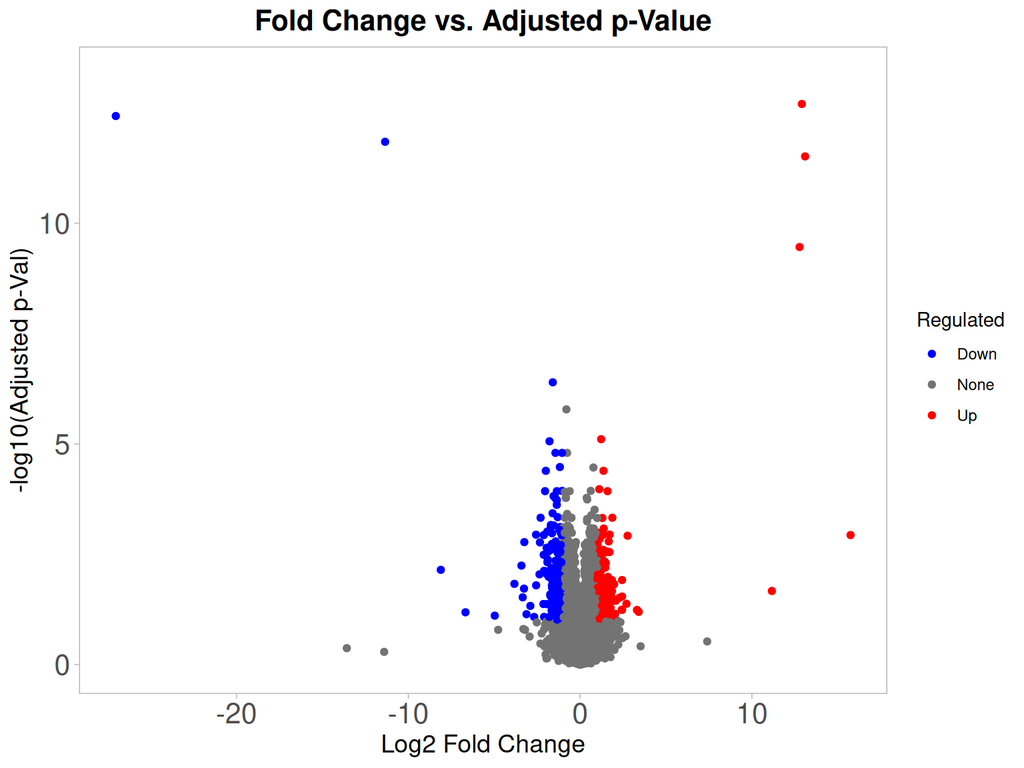

```r
if (!is.null(params$vol_data) && !is.null(params$vol_data$data)) {
  p <- plot_volcano(
    data = params$vol_data$data,
    plot_colors = params$plot_colors,
    anotate_genes = params$gene_labels_volcano
  )
  p <- refine_ggplot2(
    p = p,
    gridline = params$plot_grid_lines,
    ggplot2_theme = params$ggplot2_theme
  )
  print(p)
}
```